# Task4_Chiara_Laudani

Chiara Laudani

11/8/2019

The first task for this week is to calculate the total Sales by month for the last 3 months of 2017, for Region 1 and Region 9, in the Customer_Segment “Corporate” and “Consumer”.

Table 1

| Region | Month_Year | Total_Sales |
| --- | --- | --- |
| Region 1 | Oct 2017 | 1110.850 |
| Region 1 | Nov 2017 | 18045.310 |
| Region 1 | Dec 2017 | 13470.898 |
| Region 9 | Oct 2017 | 22690.321 |
| Region 9 | Nov 2017 | 5655.460 |
| Region 9 | Dec 2017 | 9377.647 |

The second task asks us to make a plot of the monthly total Sales in Region 1 and Region 13 in 2015, 2016 and 2017.

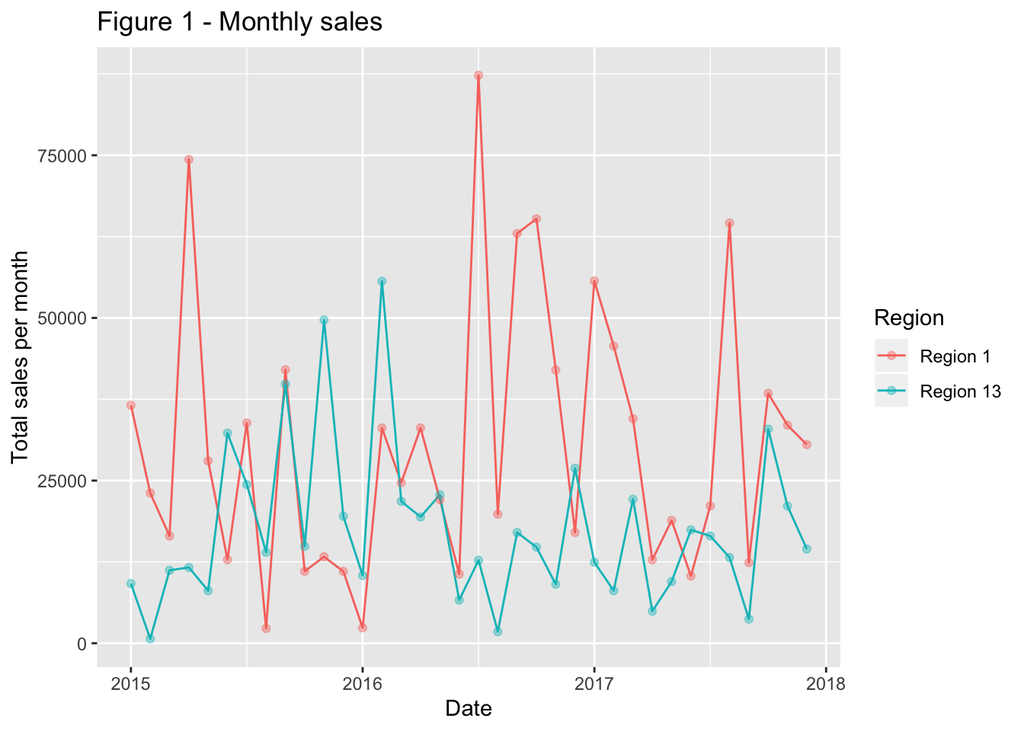

Task 3 asks to identify the months where the total Sales in Region 13 is greater than the total Sales in Region 1.

Table 2

| Month_Year | Region 1 | Region 13 |
| --- | --- | --- |
| Jun 2015 | 12844.97 | 32306.88 |
| Aug 2015 | 2266.96 | 13985.22 |
| Oct 2015 | 11058.13 | 14885.24 |
| Nov 2015 | 13290.26 | 49685.99 |
| Dec 2015 | 11048.17 | 19514.99 |
| Jan 2016 | 2362.43 | 10407.92 |
| Feb 2016 | 33085.29 | 55631.95 |
| May 2016 | 22068.67 | 22821.70 |
| Dec 2016 | 17020.27 | 26889.71 |
| Jun 2017 | 10335.31 | 17430.46 |

Task 4 is to find the average Profit per Customer_Segment and Product_Category in 2017, for all regions except Region 3, 5 and 8.

Table 3

| Customer_Segment | Product_Category | average_profit |
| --- | --- | --- |
| Small Business | Technology | 544.442933 |
| Corporate | Technology | 413.915696 |
| Home Office | Technology | 271.119368 |
| Consumer | Technology | 223.123188 |
| Corporate | Office Supplies | 164.827620 |
| Consumer | Office Supplies | 107.459323 |
| Small Business | Office Supplies | 93.995230 |
| Home Office | Office Supplies | 71.364500 |
| Consumer | Furniture | 19.551912 |
| Small Business | Furniture | 16.874722 |
| Home Office | Furniture | 7.511408 |
| Corporate | Furniture | -88.222121 |

The segment which produced the highest average profit was:

| Customer_Segment | Product_Category | average_profit |
| --- | --- | --- |
| Small Business | Technology | 544.4429 |

The final task, Taks 5, asks to estimate a SARIMA model on the aggregated monthly Order_Quantity in the Customer_Segment; Small Business and Product_Category; Office Supplies. We are asked to iterate the following SARIMA parameters:

- p and q over 0,1,2,3,4,
- d and D over 0,1,
- P and Q over 0,1,2,3,4,
- S fixed at 12

This gives a total of 2500 models.

To estimate these models we take the monthly data from 2014 through 2016 first

```
## # A tibble: 36 x 2
##    Order_Date Monthly_Order_Quantity
##    <yearmon>                   <int>
##  1 Jan 2014                      463
##  2 Feb 2014                      293
##  3 Mar 2014                      431
##  4 Apr 2014                      439
##  5 May 2014                      773
##  6 Jun 2014                      404
##  7 Jul 2014                      352
##  8 Aug 2014                      452
##  9 Sep 2014                      339
## 10 Oct 2014                      334
## # … with 26 more rows
```

and then take the same data for 2017, which will be used as the benchmark.

```
## # A tibble: 12 x 2
##    Order_Date Monthly_Order_Quantity
##    <yearmon>                   <int>
##  1 Jan 2017                      426
##  2 Feb 2017                      236
##  3 Mar 2017                      415
##  4 Apr 2017                      461
##  5 May 2017                      418
##  6 Jun 2017                      240
##  7 Jul 2017                      533
##  8 Aug 2017                      560
##  9 Sep 2017                      205
## 10 Oct 2017                      674
## 11 Nov 2017                      345
## 12 Dec 2017                      324
```

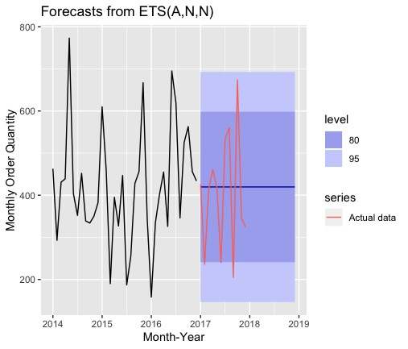

Figure 2

and was found with the following code:

```r
arima_model %>%
  forecast() %>%
  autoplot

TS <- ts(q5_data$Monthly_Order_Quantity,
         start = c(2014,1), end = c(2016,12), frequency = 12)

p <- TS %>%
  forecast() %>%
  autoplot(xlab = "Month-Year",
           ylab = "Monthly Order Quantity") +
  autolayer(ts(q5_2017$Monthly_Order_Quantity,
               start=c(2017,1), end=c(2017,12), frequency=12),
            series="Actual data")
```

> Call: arima(x = as.numeric(q5_data$Monthly_Order_Quantity), order = c(p, d, q), seasonal = list(order = c(P, D, Q), period = 12))

> Coefficients: ar1 ar2 ma1 ma2 ma3 sma1 0.0524 0.6402 0.2123 -0.9999 -0.2123 -0.4498 s.e. 0.2516 0.1685 0.3429 0.2025 0.2748 0.5213 sma2 intercept -0.5502 415.2345 s.e. 0.3676 11.6793

> sigma^2 estimated as 9065: log likelihood = -223.44, aic = 464.89